# Healthcare Feature Engineering - Using PCA & KNN

- Section 1: data preparation
  - Section 1.1: Load data
  - Section 1.2: data preparation
- Section 2: Feature engineering
- Section 3: Using PCA and KNN for Feature1-9
  - Section 3.1: Using PCA for Feature1-9
  - Section 3.2: Using KNN for Feature1-9
- Section 4: Using PCA and KNN for Feature10-15
  - Section 4.1: Using PCA for Feature10-15
  - Section 4.2: Using KNN for Feature10-15

## Section 1: Data preparation

### Section 1.1: Load Data

- Import packages and data
- Rename column
- Change data type and transfer spending amount with dollar sign into numeric
- Understand the data strcuture.

```python
import pandas as pd
import numpy as np
import matplotlib.pyplot as plt
import seaborn as sns
%matplotlib inline
```

```python
data = pd.read_csv('inpatientCharges.csv')
data.info()
```

```
<class 'pandas.core.frame.DataFrame'>
RangeIndex: 163065 entries, 0 to 163064
Data columns (total 12 columns):
 #   Column                                Non-Null Count   Dtype
---  ------                                --------------   -----
 0   DRG Definition                        163065 non-null  object
 1   Provider Id                           163065 non-null  int64
 2   Provider Name                         163065 non-null  object
 3   Provider Street Address               163065 non-null  object
 4   Provider City                         163065 non-null  object
 5   Provider State                        163065 non-null  object
 6   Provider Zip Code                     163065 non-null  int64
 7   Hospital Referral Region Description  163065 non-null  object
 8    Total Discharges                     163065 non-null  int64
 9    Average Covered Charges              163065 non-null  object
 10   Average Total Payments               163065 non-null  object
 11  Average Medicare Payments             163065 non-null  object
dtypes: int64(3), object(9)
memory usage: 14.9+ MB
```

```python
data.columns = ['DRG','Provider_Id', 'Provider_Name','Provider_StreetAddress','Provider_City',
               'Provider_State','Provider_Zipcode','Hospital_referral_region_desp',
                'Total_Discharges','Average_Covered_Charges','Average_Total_Payments',
                'Average_Medicare_Payment']
data = data.drop('Average_Covered_Charges',axis=1)
```

```python
data.head()
```

|  | DRG | Provider_Id | Provider_Name | Provider_StreetAddress | Provider_City | Provider_State | Provider_Zipcode | Hospital_referral_region_desp | Total_Discharges | Average_Total_Payments | Average_Medicare_Payment |
| --- | --- | --- | --- | --- | --- | --- | --- | --- | --- | --- | --- |
| 0 | 039 - EXTRACRANIAL PROCEDURES W/O CC/MCC | 10001 | SOUTHEAST ALABAMA MEDICAL CENTER | 1108 ROSS CLARK CIRCLE | DOTHAN | AL | 36301 | AL - Dothan | 91 | $5777.24 | $4763.73 |
| 1 | 039 - EXTRACRANIAL PROCEDURES W/O CC/MCC | 10005 | MARSHALL MEDICAL CENTER SOUTH | 2505 U S HIGHWAY 431 NORTH | BOAZ | AL | 35957 | AL - Birmingham | 14 | $5787.57 | $4976.71 |
| 2 | 039 - EXTRACRANIAL PROCEDURES W/O CC/MCC | 10006 | ELIZA COFFEE MEMORIAL HOSPITAL | 205 MARENGO STREET | FLORENCE | AL | 35631 | AL - Birmingham | 24 | $5434.95 | $4453.79 |
| 3 | 039 - EXTRACRANIAL PROCEDURES W/O CC/MCC | 10011 | ST VINCENT'S EAST | 50 MEDICAL PARK EAST DRIVE | BIRMINGHAM | AL | 35235 | AL - Birmingham | 25 | $5417.56 | $4129.16 |
| 4 | 039 - EXTRACRANIAL PROCEDURES W/O CC/MCC | 10016 | SHELBY BAPTIST MEDICAL CENTER | 1000 FIRST STREET NORTH | ALABASTER | AL | 35007 | AL - Birmingham | 18 | $5658.33 | $4851.44 |

```python
# Change data type and transfer spending amount with dollar sign into numeric
data['DRG'] = data['DRG'].astype('category')
data['Provider_State'] = data['Provider_State'].astype('category')
data['Provider_City'] = data['Provider_City'].astype('category')
data['Provider_Id'] = data['Provider_Id'].astype('category')
data['Average_Total_Payments'] = (data['Average_Total_Payments']
                                  .str.replace(r'[$,]', '', regex=True)
                                  .astype(float))

data['Average_Medicare_Payment'] = (data['Average_Medicare_Payment']
                                    .str.replace(r'[$,]', '', regex=True)
                                    .astype(float))
```

```python
data.info()
```

```
<class 'pandas.core.frame.DataFrame'>
RangeIndex: 163065 entries, 0 to 163064
Data columns (total 11 columns):
 #   Column                         Non-Null Count   Dtype
---  ------                         --------------   -----
 0   DRG                            163065 non-null  category
 1   Provider_Id                    163065 non-null  category
 2   Provider_Name                  163065 non-null  object
 3   Provider_StreetAddress         163065 non-null  object
 4   Provider_City                  163065 non-null  category
 5   Provider_State                 163065 non-null  category
 6   Provider_Zipcode               163065 non-null  int64
 7   Hospital_referral_region_desp  163065 non-null  object
 8   Total_Discharges               163065 non-null  int64
 9   Average_Total_Payments         163065 non-null  float64
 10  Average_Medicare_Payment       163065 non-null  float64
dtypes: category(4), float64(2), int64(2), object(3)
memory usage: 9.9+ MB
```

## Section 2: Feature Engineering

```python
#Create the Feature 1：Ratio of a Hospital's "Average_Total_Payment" to the State Average_Total_Payment By DRG
benchmark_by_stateDRG = data.groupby(['Provider_State','DRG'], observed=True)['Average_Total_Payments'].mean().reset_index()
benchmark_by_stateDRG.columns = ['Provider_State','DRG','Avg_Payment_ByStateDRG']
F123 = pd.merge(data, benchmark_by_stateDRG, how='left', on=['Provider_State', 'DRG'])
F123['Hospital_Average_Total_Payments_bySTDRG'] = F123['Average_Total_Payments'] / F123['Avg_Payment_ByStateDRG'].replace(0, np.nan)
```

```python
#Feature 2: Ratio of the "Average_Total_Payment" in a City to the State Average_Total_Payment By DRG
city_avg_payment = F123.groupby(['Provider_City', 'DRG'], observed = True)['Average_Total_Payments'].mean().reset_index()
city_avg_payment.columns = ['Provider_City', 'DRG', 'City_Avg_Payment']
F123 = pd.merge(F123, city_avg_payment, on=['Provider_City', 'DRG'], how='left')
F123['City_to_State_Payment_Ratio'] = F123['City_Avg_Payment'] / F123['Avg_Payment_ByStateDRG']
```

```python
#Feature3: Ratio of Provider Average Payment to State Average Payment by DRG
provider_avg_payment = data.groupby(['Provider_Id', 'DRG'], observed = True)['Average_Total_Payments'].mean().reset_index()
provider_avg_payment.columns = ['Provider_Id', 'DRG', 'Provider_Avg_Payment']
# Merge the provider average payment with the main dataset
F123 = pd.merge(F123, provider_avg_payment, on=['Provider_Id', 'DRG'], how='left')
# Calculate Feature 3: Ratio of Provider Average Payment to State Average Payment by DRG
F123['Provider_to_State_Payment_Ratio'] = F123['Provider_Avg_Payment'] / F123['Avg_Payment_ByStateDRG']
```

```python
#Feature 4: Ratio of a hospital's discharge to the state discharge by DRG
# Create benchmark for State Total_Discharges by DRG
benchmark_discharges_by_stateDRG = data.groupby(['Provider_State', 'DRG'], observed=True)['Total_Discharges'].sum().reset_index()
benchmark_discharges_by_stateDRG.columns = ['Provider_State', 'DRG', 'Total_Discharges_ByStateDRG']
F345 = pd.merge(data, benchmark_discharges_by_stateDRG, how='left', on=['Provider_State', 'DRG'])
# Calculate Feature 4: Ratio of a hospital's discharge to the state discharge by DRG
F345['Hospital_to_State_Discharge_Ratio'] = F345['Total_Discharges'] / F345['Total_Discharges_ByStateDRG']
```

```python
#Feature 5： Ratio of the "Total Discharges" in a City to the State Total Discharges By DRG
city_total_discharges = F345.groupby(['Provider_City', 'DRG'], observed=True)['Total_Discharges'].sum().reset_index()
city_total_discharges.columns = ['Provider_City', 'DRG', 'City_Total_Discharges']
F345 = pd.merge(F345, city_total_discharges, on=['Provider_City', 'DRG'], how='left')
# Calculate Feature 5
F345['City_to_State_Discharge_Ratio'] = F345['City_Total_Discharges'] / F345['Total_Discharges_ByStateDRG']
```

```python
#Feature6: Ratio of Provider's Discharge to State Discharge by DRG
F345['Provider_to_State_Discharge_Ratio'] = F345['Total_Discharges'] / F345['Total_Discharges_ByStateDRG']
```

```python
# Feature 7: Ratio of a Hospital's "Average Medicare Payment" to the State Average Medicare Payment By DRG
# Create benchmark for State Average Medical Payment by DRG
benchmark_medical_payment_by_stateDRG = data.groupby(['Provider_State', 'DRG'], observed=True)['Average_Medicare_Payment'].mean().reset_index()
benchmark_medical_payment_by_stateDRG.columns = ['Provider_State', 'DRG', 'Avg_Medicare_Payment_ByStateDRG']

F789 = pd.merge(data, benchmark_medical_payment_by_stateDRG, how='left', on=['Provider_State', 'DRG'])

# Calculate Feature 7
F789['Hospital_to_State_Medicare_Payment_Ratio'] = F789['Average_Medicare_Payment'] / F789['Avg_Medicare_Payment_ByStateDRG']
```

```python
# Feature 8: Ratio of the "Average Medicare Payment" in a City to the State Average Medicare Payment By DRG
# Calculate the average Medicare payment by city and DRG
city_avg_medicare_payment = F789.groupby(['Provider_City', 'DRG'], observed=True)['Average_Medicare_Payment'].mean().reset_index()
city_avg_medicare_payment.columns = ['Provider_City', 'DRG', 'City_Avg_Medicare_Payment']
# Merge
F789 = pd.merge(F789, city_avg_medicare_payment, on=['Provider_City', 'DRG'], how='left')
# Calculate Feature 8
F789['City_to_State_Medicare_Payment_Ratio'] = F789['City_Avg_Medicare_Payment'] / F789['Avg_Medicare_Payment_ByStateDRG']
```

```python
# Feature 9: Ratio of a Provider's "Average Medicare Payment" to the State Average Medicare Payment By DRG
# Calculate Feature 9
F789['Provider_to_State_Medicare_Payment_Ratio'] = F789['Average_Medicare_Payment'] / F789['Avg_Medicare_Payment_ByStateDRG']
```

```python
# Feature 10: Ratio of Hospital's Average Payment to State Average Total Payment per Discharge by DRG
# Create benchmark for State Average Total Payment per Discharge by DRG
benchmark_payment_per_discharge_by_stateDRG = data.groupby(['Provider_State', 'DRG'], observed=True).agg({
    'Average_Total_Payments': 'sum',
    'Total_Discharges': 'sum'
}).reset_index()

benchmark_payment_per_discharge_by_stateDRG['Avg_Payment_Per_Discharge_ByStateDRG'] = (
    benchmark_payment_per_discharge_by_stateDRG['Average_Total_Payments'] /
    benchmark_payment_per_discharge_by_stateDRG['Total_Discharges']
)

benchmark_payment_per_discharge_by_stateDRG = benchmark_payment_per_discharge_by_stateDRG[['Provider_State', 'DRG', 'Avg_Payment_Per_Discharge_ByStateDRG']]

# Merge this new benchmark with the original data dataset and name it F101112
F101112 = pd.merge(data, benchmark_payment_per_discharge_by_stateDRG, how='left', on=['Provider_State', 'DRG'])

# hospital's average payment per discharge
F101112['Hospital_Avg_Payment_Per_Discharge'] = F101112['Average_Total_Payments'] / F101112['Total_Discharges']
# Calculate Feature 10
F101112['Hospital_to_State_Payment_Per_Discharge_Ratio'] = F101112['Hospital_Avg_Payment_Per_Discharge'] / F101112['Avg_Payment_Per_Discharge_ByStateDRG']
```

```python
# Feature 11: Ratio of Average Payment by City to State Average Total Payment per Discharge by DRG
# Calculate the average payment per discharge by city and DRG
city_avg_payment_per_discharge = F101112.groupby(['Provider_City', 'DRG'], observed=True).agg({
    'Average_Total_Payments': 'sum',
    'Total_Discharges': 'sum'
}).reset_index()

city_avg_payment_per_discharge['City_Avg_Payment_Per_Discharge'] = (
    city_avg_payment_per_discharge['Average_Total_Payments'] /
    city_avg_payment_per_discharge['Total_Discharges']
)
# Merge the city average payment per discharge with the origin dataset
F101112 = pd.merge(F101112, city_avg_payment_per_discharge[['Provider_City', 'DRG', 'City_Avg_Payment_Per_Discharge']],
                   on=['Provider_City', 'DRG'], how='left')

# Calculate Feature 11
F101112['City_to_State_Payment_Per_Discharge_Ratio'] = F101112['City_Avg_Payment_Per_Discharge'] / F101112['Avg_Payment_Per_Discharge_ByStateDRG']
```

```python
# Feature 12: Ratio of Provider's Average Payment per Discharge to State Average Payment per Discharge by DRG
F101112['Provider_Avg_Payment_Per_Discharge'] = F101112['Average_Total_Payments'] / F101112['Total_Discharges']
F101112['Provider_to_State_Payment_Per_Discharge_Ratio'] = F101112['Provider_Avg_Payment_Per_Discharge'] / F101112['Avg_Payment_Per_Discharge_ByStateDRG']
```

```python
# Feature 13: Ratio of Hospital's Average Medicare Payment per discharge to State Average Payment per discharge by DRG
# Create benchmark for State Average Medicare Payment per Discharge by DRG
benchmark_medicare_per_discharge_by_stateDRG = data.groupby(['Provider_State', 'DRG'], observed = True).agg({
    'Average_Medicare_Payment': 'sum',
    'Total_Discharges': 'sum'
}).reset_index()

benchmark_medicare_per_discharge_by_stateDRG['Avg_Medicare_Per_Discharge_ByStateDRG'] = (
    benchmark_medicare_per_discharge_by_stateDRG['Average_Medicare_Payment'] /
    benchmark_medicare_per_discharge_by_stateDRG['Total_Discharges']
)

benchmark_medicare_per_discharge_by_stateDRG = benchmark_medicare_per_discharge_by_stateDRG[['Provider_State', 'DRG', 'Avg_Medicare_Per_Discharge_ByStateDRG']]
# Merge this new benchmark with the original data dataset
F131415 = pd.merge(data, benchmark_medicare_per_discharge_by_stateDRG, how='left', on=['Provider_State', 'DRG'])
# Calculate the hospital's average Medicare payment per discharge
F131415['Hospital_Avg_Medicare_Per_Discharge'] = F131415['Average_Medicare_Payment'] / F131415['Total_Discharges']
# Calculate Feature 13
F131415['Hospital_to_State_Medicare_Per_Discharge_Ratio'] = F131415['Hospital_Avg_Medicare_Per_Discharge'] / F131415['Avg_Medicare_Per_Discharge_ByStateDRG']
```

```python
# Feature 14: Ratio of Average Medicare Payment by City per discharge to State Average Payment per discharge on DRG
# Calculate the average Medicare payment per discharge by city and DRG
city_avg_medicare_per_discharge = F131415.groupby(['Provider_City', 'DRG'], observed = True).agg({
    'Average_Medicare_Payment': 'sum',
    'Total_Discharges': 'sum'
}).reset_index()

city_avg_medicare_per_discharge['City_Avg_Medicare_Per_Discharge'] = (
    city_avg_medicare_per_discharge['Average_Medicare_Payment'] /
    city_avg_medicare_per_discharge['Total_Discharges']
)

# Merge with the main dataset
F131415 = pd.merge(F131415, city_avg_medicare_per_discharge[['Provider_City', 'DRG', 'City_Avg_Medicare_Per_Discharge']],
                   on=['Provider_City', 'DRG'], how='left')

# Calculate Feature 14
F131415['City_to_State_Medicare_Per_Discharge_Ratio'] = F131415['City_Avg_Medicare_Per_Discharge'] / F131415['Avg_Medicare_Per_Discharge_ByStateDRG']
```

```python
# Feature 15: Ratio of Provider's Average Medicare Payment per discharge to State Average Payment per discharge by DRG
# Calculate Feature 15
F131415['Provider_Avg_Medicare_Per_Discharge'] = F131415['Average_Medicare_Payment'] / F131415['Total_Discharges']
F131415['Provider_to_State_Medicare_Per_Discharge_Ratio'] = F131415['Provider_Avg_Medicare_Per_Discharge'] / F131415['Avg_Medicare_Per_Discharge_ByStateDRG']
```

```python
# Combine all features into one DataFrame
features = pd.DataFrame()
features['F1'] = F123['Hospital_Average_Total_Payments_bySTDRG']
features['F2'] = F123['City_to_State_Payment_Ratio']
features['F3'] = F123['Provider_to_State_Payment_Ratio']
features['F4'] = F345['Hospital_to_State_Discharge_Ratio']
features['F5'] = F345['City_to_State_Discharge_Ratio']
features['F6'] = F345['Provider_to_State_Discharge_Ratio']
features['F7'] = F789['Hospital_to_State_Medicare_Payment_Ratio']
features['F8'] = F789['City_to_State_Medicare_Payment_Ratio']
features['F9'] = F789['Provider_to_State_Medicare_Payment_Ratio']
features = features.fillna(features.mean())
```

## Section 3: Using PCA and KNN for Feature1-9

### Section 3.1: Using PCA for Feature1-9

#### PCA which is Principal Component Analysis is a method that reduces the dimensionality of a dataset by transforming correlated features into a smaller set of uncorrelated components, making it easier to spot patterns and identify outliers in the data. Apply the PCA model to calculate the outlier score for each hospital based on its distance from the main cluster in this simplified space. The contamination = 0.05 here means 5% of the data points will be considered as outliers.

##### Here, I divided my features into two groups: features 1-9 and features 10-15, because I noticed that these two groups have different scopes. Specifically, features 1-9 focus on comparing hospital payment and discharge ratios relative to state or city benchmarks, while features 10-15 concentrate on similar ratios but specifically for Medicare payments and payments per discharge. This distinction allows for a more targeted analysis of general payment patterns versus Medicare-specific and discharge-specific payment behaviors.

```python
#!pip install pyod
#!pip install combo
```

#### Build the PCA model for both train and test

```python
from sklearn.model_selection import train_test_split
from pyod.models.pca import PCA
```

```python
# Split the data into train and test
X_train, X_test = train_test_split(features, test_size=0.2, random_state=42)

# Apply PCA-based outlier detection
pca = PCA(contamination=0.05)
pca.fit(X_train)

# Get predictions and scores
y_train_pred = pca.labels_  # binary labels (0: inliers, 1: outliers)
y_train_scores = pca.decision_scores_
y_test_scores = pca.decision_function(X_test)
y_test_pred = pca.predict(X_test)
```

#### Determine a reasonable threshold

```python
print("The threshold for the defined contamination rate:" , pca.threshold_)
```

```
The threshold for the defined contamination rate: 1.1184134043083815e+32
```

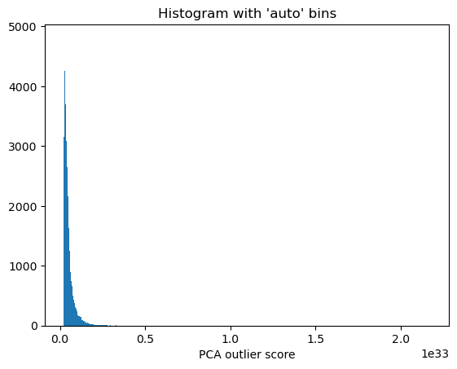

```python
import matplotlib.pyplot as plt
plt.hist(y_train_scores, bins='auto')  # arguments are passed to np.histogram
plt.title("Histogram with 'auto' bins")
plt.xlabel('PCA outlier score')
plt.show()
```

#### Present the descriptive statistics of the normal and the abnormal groups

```python
# Create feature list
feature_list = ['F1', 'F2', 'F3', 'F4', 'F5', 'F6', 'F7', 'F8', 'F9']

def descriptive_stat_threshold(X, scores, threshold):
    normal_mask = scores <= threshold
    anomaly_mask = scores > threshold

    normal_stats = X[normal_mask].describe()
    anomaly_stats = X[anomaly_mask].describe()

    summary_df = pd.DataFrame({
        'Group': ['Normal', 'Outlier'],
        'Count': [normal_mask.sum(), anomaly_mask.sum()],
        'Count %': [normal_mask.mean() * 100, anomaly_mask.mean() * 100]
    })

    for i, feature in enumerate(feature_list, 1):
        summary_df[f'Feature_{i}'] = [
            X[normal_mask][feature].mean(),
            X[anomaly_mask][feature].mean()
        ]

    summary_df['Anomaly_Score'] = [
        scores[normal_mask].mean(),
        scores[anomaly_mask].mean()
    ]

    return summary_df

# Apply the function
descriptive_stat_threshold(X_train, y_train_scores, threshold)
```

|  | Group | Count | Count % | Feature_1 | Feature_2 | Feature_3 | Feature_4 | Feature_5 | Feature_6 | Feature_7 | Feature_8 | Feature_9 | Anomaly_Score |
| --- | --- | --- | --- | --- | --- | --- | --- | --- | --- | --- | --- | --- | --- |
| 0 | Normal | 123929 | 94.999693 | 0.978141 | 0.988640 | 0.978141 | 0.025566 | 0.066766 | 0.025566 | 0.976527 | 0.988215 | 0.976527 | 4.406378e+31 |
| 1 | Outlier | 6523 | 5.000307 | 1.421854 | 1.242241 | 1.421854 | 0.130593 | 0.343784 | 0.130593 | 1.453436 | 1.256853 | 1.453436 | 1.666462e+32 |

#### Outliers have significant higher values in features like Feature5, Feature2, Feature3, Feature5 and Feature7. These features may related to higher total paymentsor discharges ratios when compare to state or city benchmarks. An outlier hospital with high Feature7 and Feature8 values could indicate unusual high Medicare payments relative to others in the area, which could figure out overbilling or special cases in treatment.

### Section 3.2: Using KNN for Feature1-9

#### KNN which is K-Nearest Neighbors is an algorithm that identifies each data point's closest neighbors based on distance in feature space. For outlier detection, KNN flags points with unusual large distances to their nearest neighbors as outliers, refering to do not following typical patterns, like abnormal billing or discharge rates in hospitals here. Here contamination = 0.05, means 5% of the data points will be considered as outliers.

```python
# train kNN detector
from pyod.models.knn import KNN
knn = KNN(contamination=0.05)
knn.fit(X_train)

# Training data
y_train_scores = knn.decision_function(X_train)
y_train_pred = knn.predict(X_train)

# Test data
y_test_scores = knn.decision_function(X_test)
y_test_pred = knn.predict(X_test)

def count_stat(vector):
    unique, counts = np.unique(vector, return_counts=True)
    return dict(zip(unique, counts))

# Threshold for the defined contamination rate
print("The threshold for the defined contamination rate:" , knn.threshold_)
```

```
The threshold for the defined contamination rate: 0.09142290514811306
```

```python
knn.get_params()
```

```
{'algorithm': 'auto',
 'contamination': 0.05,
 'leaf_size': 30,
 'method': 'largest',
 'metric': 'minkowski',
 'metric_params': None,
 'n_jobs': 1,
 'n_neighbors': 5,
 'p': 2,
 'radius': 1.0}
```

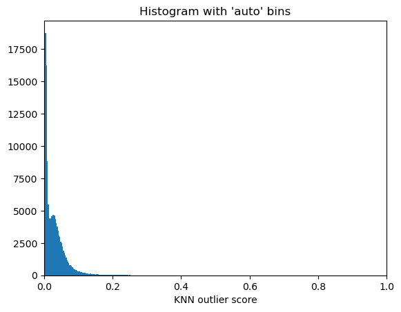

```python
plt.hist(y_train_scores, bins=5000)
plt.title("Histogram with 'auto' bins")
plt.xlabel('KNN outlier score')
plt.xlim(0, 1)

plt.show()
```

#### This histogram shows the distribution of KNN outliers scores for each data point, where most hospitals have low score and clustered on the left. This indicates that the majority of hospitals have billing patterns similar to their nearest neighbors. However, small group of hospitals billing have higher scores which specially higher than 0.0914 (threshold here), indicating they deviate significantly from the norm. These high-score hospitals are potential outliers, which may have unusual billing. Identifying those outliers can help focus reviews on hospital, revealing cases of overbiling, underbilling or other anomalies.

```python
def knn_stat_summary(X, pred_scores, threshold):
    # Create DataFrame and set columns
    df = pd.DataFrame(X)
    df['Anomaly_Score'] = pred_scores
    df['Group'] = np.where(df['Anomaly_Score'] < threshold, 'Normal', 'Outlier')

    # Count and percentage of each group
    cnt = df.groupby('Group')['Anomaly_Score'].count().reset_index().rename(columns={'Anomaly_Score': 'Count'})
    cnt['Count %'] = (cnt['Count'] / cnt['Count'].sum()) * 100

    # Calculate mean statistics
    stat = df.groupby('Group').mean().round(2).reset_index()

    # Merge count and average statistics
    stat = cnt.merge(stat, left_on='Group', right_on='Group')
    return stat

# Apply the function
X_data=X_train.copy()
knn_summary_stats = knn_stat_summary(X_data, y_train_scores, knn.threshold_)
knn_summary_stats
```

|  | Group | Count | Count % | F1 | F2 | F3 | F4 | F5 | F6 | F7 | F8 | F9 | Anomaly_Score |
| --- | --- | --- | --- | --- | --- | --- | --- | --- | --- | --- | --- | --- | --- |
| 0 | Normal | 124657 | 95.557753 | 0.99 | 0.99 | 0.99 | 0.03 | 0.06 | 0.03 | 0.99 | 1.00 | 0.99 | 0.03 |
| 1 | Outlier | 5795 | 4.442247 | 1.25 | 1.15 | 1.25 | 0.13 | 0.43 | 0.13 | 1.18 | 1.11 | 1.18 | 0.15 |

### Here the multiple KNN models with varying numbers of nearest neighbors k to evalute outlier scores and then averages those scores for a more robust outlier detection. For each k, KNN model is trained on the trainning data, and the decision_function calculates outlier scores, indicating how far each points is from its neighbors.

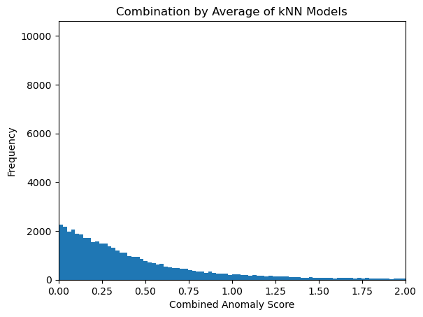

```python
from pyod.utils.utility import standardizer
from pyod.models.combination import average
k_list = [10, 20, 30, 40, 50]
n_clf = len(k_list)


train_scores = np.zeros([X_train.shape[0], n_clf])
test_scores = np.zeros([X_test.shape[0], n_clf])

# Modeling
for i in range(n_clf):
    k = k_list[i]
    clf = KNN(n_neighbors=k, method='largest')
    clf.fit(X_train)

    train_scores[:, i] = clf.decision_function(X_train)
    test_scores[:, i] = clf.decision_function(X_test)

train_scores_norm, test_scores_norm = standardizer(train_scores, test_scores)

y_train_by_average = average(train_scores_norm)
y_test_by_average = average(test_scores_norm)

# Plotting the combined scores
plt.hist(y_train_by_average, bins='auto')
plt.title("Combination by Average of kNN Models")
plt.xlabel('Combined Anomaly Score')
plt.ylabel('Frequency')
plt.xlim(0,2)
plt.show()
```

#### This Histogram shows the distribution of combined KNN outlier scores across all data points. Most points have low scores, indicating they are close to their nearest neighbors. A smaller number of points have higher scores, suggesting they are more isolated from other data points. Those higher scores might represent the unusual billing.

```python
from sklearn.neighbors import NearestNeighbors
from sklearn.cluster import KMeans

def knn_kmeans_clustering(X, n_neighbors=10, n_clusters=2):
    # Step 1: Fit Nearest Neighbors
    my_knn = NearestNeighbors(n_neighbors=n_neighbors, algorithm='ball_tree').fit(X)
    distances, indices = my_knn.kneighbors(X, return_distance=True)

    # Step 2: Use KMeans on the original data
    kmeans = KMeans(n_clusters=n_clusters, random_state=0).fit(X)

    # Get the labels and centroids
    labels = kmeans.labels_
    centroids = kmeans.cluster_centers_

    return distances, indices, labels, centroids

# Apply the function
distances, indices, labels, centroids = knn_kmeans_clustering(X_train, n_neighbors=10, n_clusters=2)

# Print results
print("Distances to nearest neighbors:\n", distances)
print("Indices of nearest neighbors:\n", indices)
print("KMeans labels:\n", labels)
print("KMeans centroids:\n", centroids)
```

```
Distances to nearest neighbors:
 [[0.         0.02534569 0.02846903 ... 0.03347917 0.0335037  0.03490769]
 [0.         0.00690619 0.00712171 ... 0.01037193 0.01178536 0.01438259]
 [0.         0.01483667 0.02436253 ... 0.0301097  0.03194502 0.03339612]
 ...
 [0.         0.00747688 0.01527356 ... 0.01554061 0.01577468 0.01590503]
 [0.         0.03079376 0.0457159  ... 0.06506453 0.06983191 0.07082232]
 [0.         0.0457118  0.06090297 ... 0.06925657 0.07237108 0.07350576]]
Indices of nearest neighbors:
 [[     0  15972   4990 ...  73293 118147  95604]
 [     1  68956  91257 ... 112560  90773   4385]
 [     2 124504  44764 ...  78839 127529   8311]
 ...
 [130449  71836  42568 ...  12071 111964 123441]
 [130450  83637  58675 ...  13341  50993  41275]
 [130451 115730  59601 ...  55646  36094  80022]]
KMeans labels:
 [1 1 1 ... 1 0 1]
KMeans centroids:
 [[1.31274008 1.21557324 1.31274008 0.03094628 0.11479552 0.03094628
  1.35143542 1.24232841 1.35143542]
 [0.93225632 0.95463757 0.93225632 0.0307891  0.07317122 0.0307891
  0.92388085 0.94920557 0.92388085]]
```

##### KNN calculates the distances and indices of each point’s 10 nearest neighbors, helping identify isolated or unusual points. It then applies K-Means clustering with 2 clusters to label each point and find centroids, grouping similar patterns together. The results can help detect outliers based on both distance to neighbors and cluster membership, highlighting points that deviate from typical data patterns. And points with large neighbor distances or different cluster labels are potential outliers, representing unusual patterns in the data.

## Section 4: Using PCA and KNN for Feature10-15

##### Similar explaination as section3

### Section 4.1: Using PCA for Feature10-15

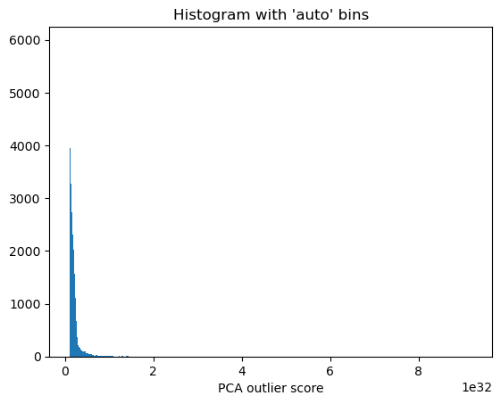

```python
features= pd.DataFrame()
features['F10'] = F101112['Hospital_to_State_Payment_Per_Discharge_Ratio']
features['F11'] = F101112['City_to_State_Payment_Per_Discharge_Ratio']
features['F12'] = F101112['Provider_to_State_Payment_Per_Discharge_Ratio']
features['F13'] = F131415['Hospital_to_State_Medicare_Per_Discharge_Ratio']
features['F14'] = F131415['City_to_State_Medicare_Per_Discharge_Ratio']
features['F15'] = F131415['Provider_to_State_Medicare_Per_Discharge_Ratio']
# Split the data into train and test
X_train, X_test = train_test_split(features, test_size=0.2, random_state=42)

# Apply PCA-based outlier detection
pca = PCA(contamination=0.05)
pca.fit(X_train)

# Get predictions and scores
y_train_pred = pca.labels_  # binary labels (0: inliers, 1: outliers)
y_train_scores = pca.decision_scores_
y_test_scores = pca.decision_function(X_test)
y_test_pred = pca.predict(X_test)
import matplotlib.pyplot as plt
plt.hist(y_train_scores, bins='auto')  # arguments are passed to np.histogram
plt.title("Histogram with 'auto' bins")
plt.xlabel('PCA outlier score')
plt.show()
```

#### Determine a reasonable threshold

```python
# Get the threshold from PCA model
threshold = pca.threshold_
print(f"PCA Threshold: {threshold}")

# Create feature list
feature_list = ['F10', 'F11', 'F12', 'F13', 'F14', 'F15']

def descriptive_stat_threshold(X, scores, threshold):
    normal_mask = scores <= threshold
    anomaly_mask = scores > threshold

    normal_stats = X[normal_mask].describe()
    anomaly_stats = X[anomaly_mask].describe()

    summary_df = pd.DataFrame({
        'Group': ['Normal', 'Outlier'],
        'Count': [normal_mask.sum(), anomaly_mask.sum()],
        'Count %': [normal_mask.mean() * 100, anomaly_mask.mean() * 100]
    })

    for i, feature in enumerate(feature_list, 1):
        summary_df[f'Feature_{i}'] = [
            X[normal_mask][feature].mean(),
            X[anomaly_mask][feature].mean()
        ]

    summary_df['Anomaly_Score'] = [
        scores[normal_mask].mean(),
        scores[anomaly_mask].mean()
    ]

    return summary_df

# Apply the function
descriptive_stat_threshold(X_train, y_train_scores, threshold)
```

```
PCA Threshold: 4.084908196352274e+31
```

|  | Group | Count | Count % | Feature_1 | Feature_2 | Feature_3 | Feature_4 | Feature_5 | Feature_6 | Anomaly_Score |
| --- | --- | --- | --- | --- | --- | --- | --- | --- | --- | --- |
| 0 | Normal | 123929 | 94.999693 | 1.282663 | 1.179366 | 1.282663 | 1.282502 | 1.178962 | 1.282502 | 1.663146e+31 |
| 1 | Outlier | 6523 | 5.000307 | 4.833916 | 3.492140 | 4.833916 | 4.893780 | 3.506602 | 4.893780 | 7.157260e+31 |

### Section 4.2: Using KNN for Feature10-15

```python
# train kNN detector
from pyod.models.knn import KNN
knn = KNN(contamination=0.05)
knn.fit(X_train)


y_train_scores = knn.decision_function(X_train)
y_train_pred = knn.predict(X_train)

y_test_scores = knn.decision_function(X_test)
y_test_pred = knn.predict(X_test)


def count_stat(vector):
    unique, counts = np.unique(vector, return_counts=True)
    return dict(zip(unique, counts))

# Threshold for the defined contamination rate
print("The threshold for the defined contamination rate:" , knn.threshold_)
```

```
The threshold for the defined contamination rate: 0.14105517614718285
```

```python
knn.get_params()
```

```
{'algorithm': 'auto',
 'contamination': 0.05,
 'leaf_size': 30,
 'method': 'largest',
 'metric': 'minkowski',
 'metric_params': None,
 'n_jobs': 1,
 'n_neighbors': 5,
 'p': 2,
 'radius': 1.0}
```

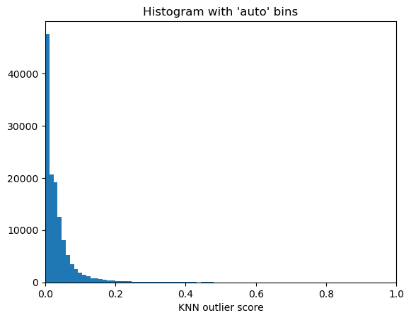

```python
plt.hist(y_train_scores, bins=5000)
plt.title("Histogram with 'auto' bins")
plt.xlabel('KNN outlier score')
plt.xlim(0, 1)

plt.show()
```

```python
def knn_stat_summary(X, pred_scores, threshold):
    df = pd.DataFrame(X)
    df['Anomaly_Score'] = pred_scores
    df['Group'] = np.where(df['Anomaly_Score'] < threshold, 'Normal', 'Outlier')

    cnt = df.groupby('Group')['Anomaly_Score'].count().reset_index().rename(columns={'Anomaly_Score': 'Count'})
    cnt['Count %'] = (cnt['Count'] / cnt['Count'].sum()) * 100

    stat = df.groupby('Group').mean().round(2).reset_index()

    stat = cnt.merge(stat, left_on='Group', right_on='Group')
    return stat

# Apply the function
X_data=X_train.copy()
knn_summary_stats = knn_stat_summary(X_data, y_train_scores, knn.threshold_)
knn_summary_stats
```

|  | Group | Count | Count % | F10 | F11 | F12 | F13 | F14 | F15 | Anomaly_Score |
| --- | --- | --- | --- | --- | --- | --- | --- | --- | --- | --- |
| 0 | Normal | 124625 | 95.533223 | 1.33 | 1.24 | 1.33 | 1.34 | 1.24 | 1.34 | 0.03 |
| 1 | Outlier | 5827 | 4.466777 | 4.22 | 2.56 | 4.22 | 4.11 | 2.47 | 4.11 | 0.38 |

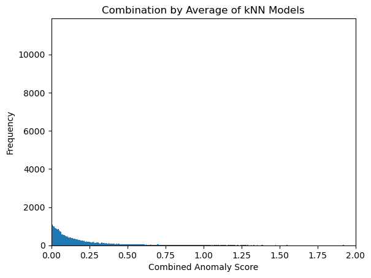

```python
from pyod.utils.utility import standardizer
from pyod.models.combination import average
# Test a range of k-neighbors from 10 to 50. There will be 5 KNN models.
k_list = [10, 20, 30, 40, 50]# , 60, 70, 80, 90, 100, 110,
           # 120, 130, 140, 150, 160, 170, 180, 190, 200]
n_clf = len(k_list)

# Prepare data frames to store the model results
train_scores = np.zeros([X_train.shape[0], n_clf])
test_scores = np.zeros([X_test.shape[0], n_clf])

# Modeling
for i in range(n_clf):
    k = k_list[i]
    clf = KNN(n_neighbors=k, method='largest')
    clf.fit(X_train)

    # Store the results in each column
    train_scores[:, i] = clf.decision_function(X_train)
    test_scores[:, i] = clf.decision_function(X_test)

# Decision scores have to be normalized before combination
train_scores_norm, test_scores_norm = standardizer(train_scores, test_scores)

# Combination by average
y_train_by_average = average(train_scores_norm)
y_test_by_average = average(test_scores_norm)

# Plotting the combined scores
plt.hist(y_train_by_average, bins='auto')  # arguments are passed to np.histogram
plt.title("Combination by Average of kNN Models")
plt.xlabel('Combined Anomaly Score')
plt.ylabel('Frequency')
plt.xlim(0,2)
plt.show()
```

```python
from sklearn.neighbors import NearestNeighbors
from sklearn.cluster import KMeans

def knn_kmeans_clustering(X, n_neighbors=10, n_clusters=2):
    # Step 1: Fit Nearest Neighbors
    my_knn = NearestNeighbors(n_neighbors=n_neighbors, algorithm='ball_tree').fit(X)
    distances, indices = my_knn.kneighbors(X, return_distance=True)

    # Step 2: Use KMeans on the original data
    kmeans = KMeans(n_clusters=n_clusters, random_state=0).fit(X)

    # Get the labels and centroids
    labels = kmeans.labels_
    centroids = kmeans.cluster_centers_

    return distances, indices, labels, centroids

# Apply the function
distances, indices, labels, centroids = knn_kmeans_clustering(X_train, n_neighbors=10, n_clusters=2)

# Print results
print("Distances to nearest neighbors:\n", distances)
print("Indices of nearest neighbors:\n", indices)
print("KMeans labels:\n", labels)
print("KMeans centroids:\n", centroids)
```

```
Distances to nearest neighbors:
 [[0.         0.00821911 0.02031629 ... 0.03231775 0.03359219 0.03359633]
 [0.         0.01078578 0.01098222 ... 0.01960985 0.0207175  0.02182141]
 [0.         0.02498242 0.03087956 ... 0.04512619 0.04794073 0.04814145]
 ...
 [0.         0.01862471 0.01887573 ... 0.02537981 0.02716658 0.02884447]
 [0.         0.01002935 0.01781354 ... 0.04661749 0.04765222 0.05265096]
 [0.         0.00713105 0.01295491 ... 0.01883325 0.01963276 0.02232703]]
Indices of nearest neighbors:
 [[     0  64461   1041 ... 107919  51633  77475]
 [     1  20701  82626 ...  13611  58857 110371]
 [     2  67796  66109 ...  51078  75094  75783]
 ...
 [130449 127056  13742 ...  27795  90153  95855]
 [130450  52109 124047 ...  93786 108834  49116]
 [130451   2275  65670 ...  38566  48389  66147]]
KMeans labels:
 [0 0 0 ... 0 0 0]
KMeans centroids:
 [[1.13644383 1.08666955 1.13644383 1.13316373 1.08461119 1.13316373]
 [3.50598517 2.61133206 3.50598517 3.54749274 2.6268231  3.54749274]]
```